# Olympics_EDA_Presentation

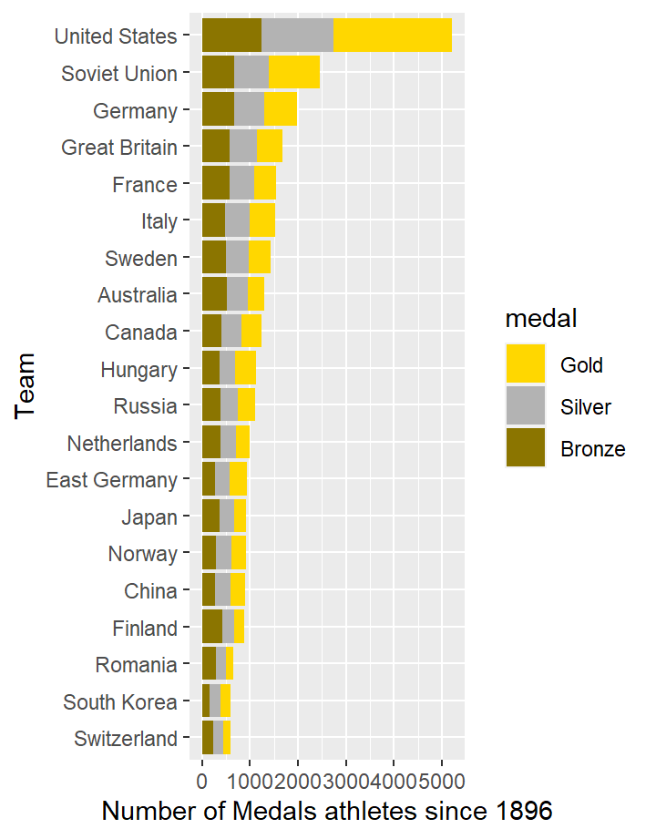

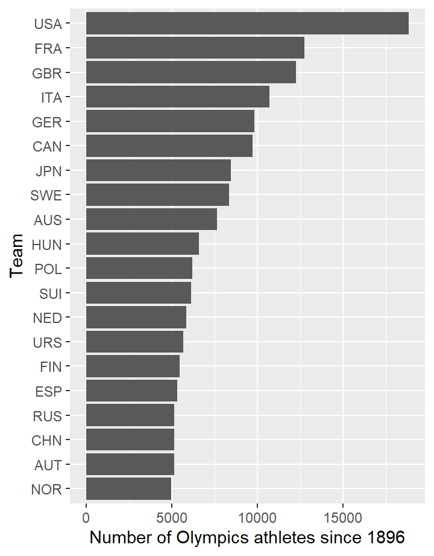

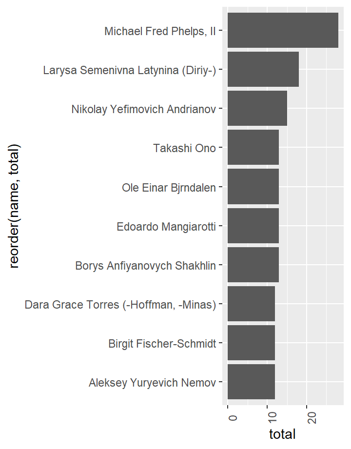

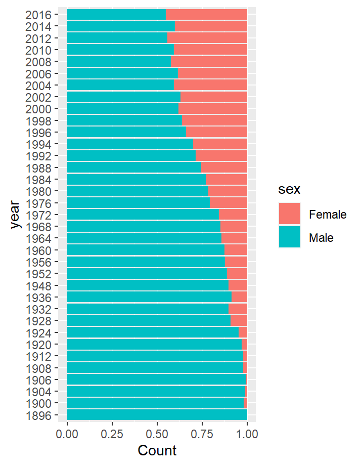

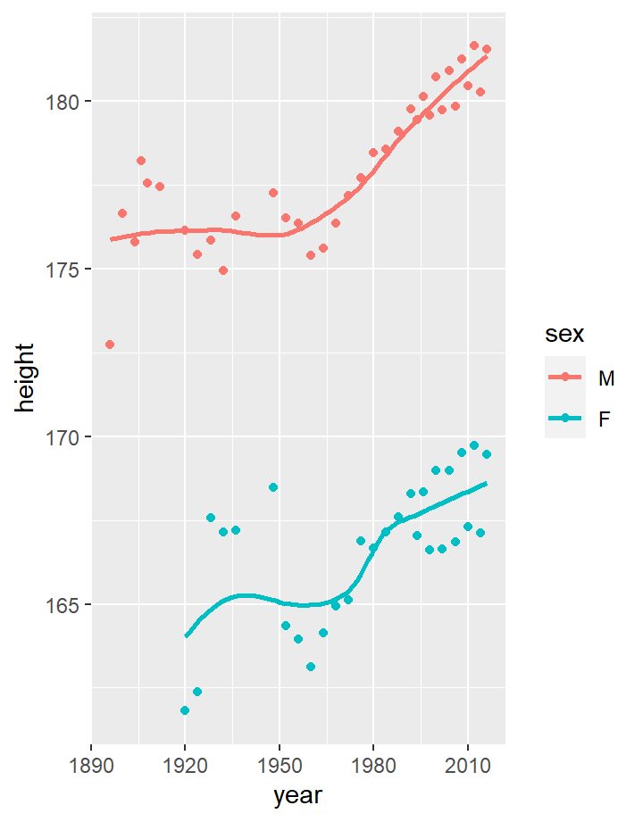

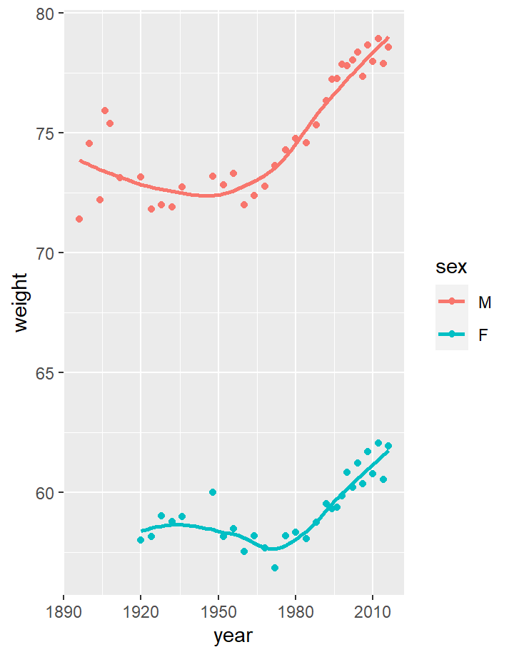

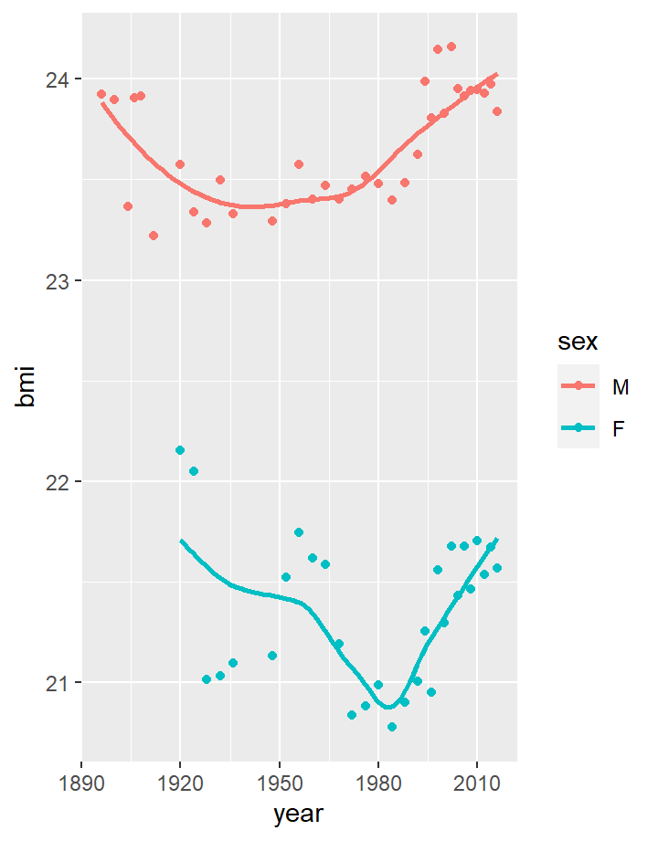

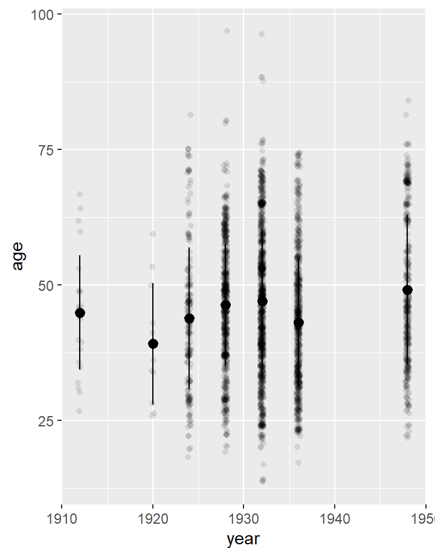

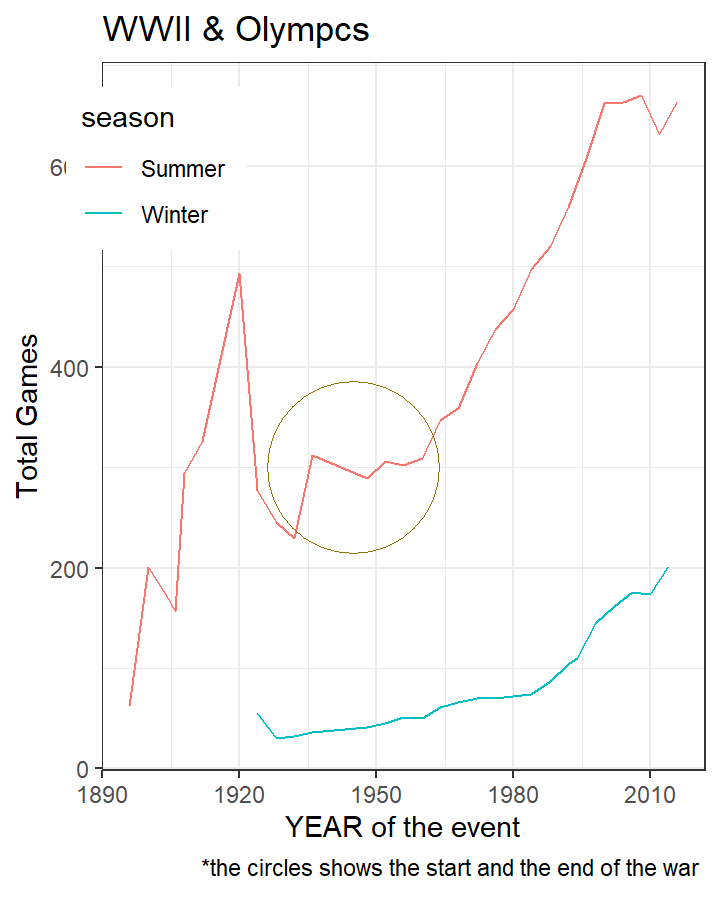

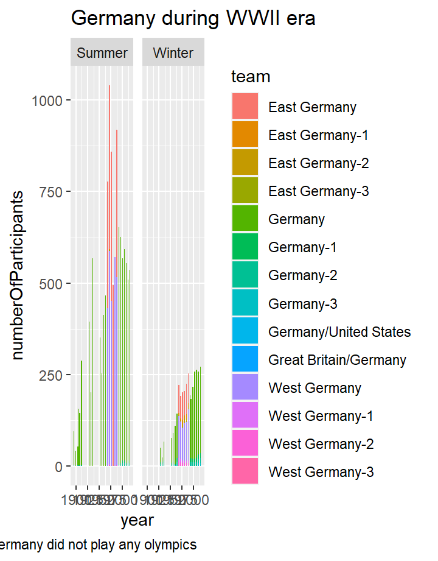

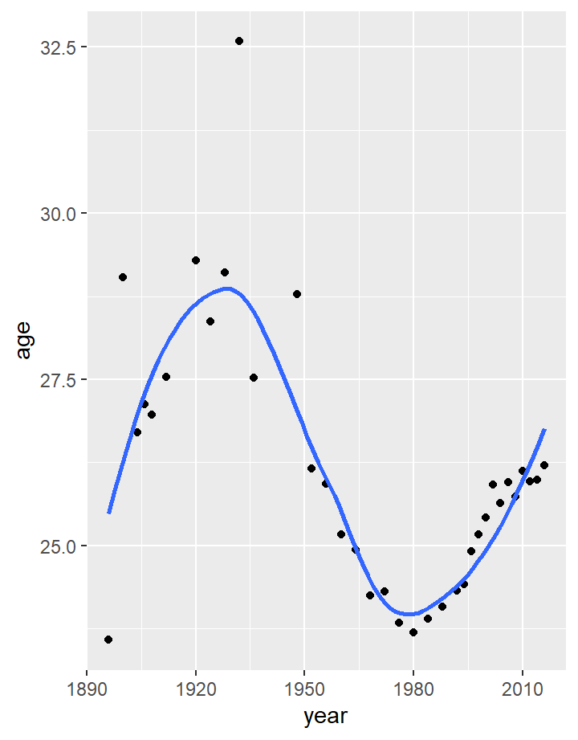

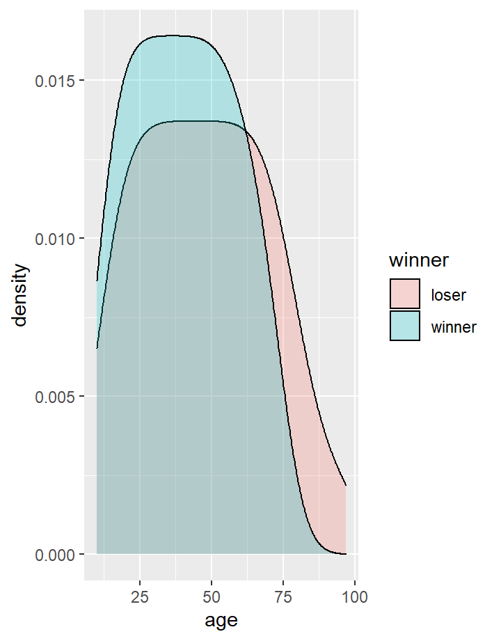

[1 more figures not shown]

# Olympics

**EDA analysis of the Olypics games**  
*By*  
Mohammed Darwish, Salman Al-Harbi, Amal alghamdi, Abdulmalik Alrebdi

**Content**

1. DATA
2. EDA
3. Problems and challenges
4. Key takeaways

# DATA

### Short description of the data

This is a historical dataset on the modern Olympic Games, including all the Games from Athens 1896 to Rio 2016, featuring summer and winter sports competitions in which thousands of athletes from around the world participate in a variety of events. The dataset contains 271116 rows and 15 columns. The Olympics is more than just a multi-sport world championship. It is a lens through which to understand the global history and countries’ cultures. The goals of the analysis are to shed light on major patterns in Olympic history. How many athletes, sports, and nations are there? Where do most athletes come from? Who wins medals?.

**The dataset contains the following variables:**

| Variable | Type | Description |
| --- | --- | --- |
| id | double | Athlete unique ID |
| name | character | Athlete Name |
| sex | character | Athlete Sex |
| age | double | Athlete Age |
| height | double | Athlete Height (cm) |
| weight | double | Athlete weight (kg) |
| team | character | Team name, typically a country name |
| noc | character | NOC 3-letter country code |
| games | character | 4-digit year + season |
| year | double | 4-digit year |
| season | character | Season |
| city | character | Host city |
| sport | character | Sport |
| event | character | Sport + Event Name |
| medal | character | Medal: Gold, Silver, Bronze, (plus NA values) |

**You can access the dataset directly from base package.**

### **The detailed summary for every type as follow**

```
 sex             age            height          weight           year
 M:196594   Min.   :10.00   Min.   :127.0   Min.   : 25.0   Min.   :1896
 F: 74522   1st Qu.:21.00   1st Qu.:168.0   1st Qu.: 60.0   1st Qu.:1960
            Median :24.00   Median :175.0   Median : 70.0   Median :1988
            Mean   :25.56   Mean   :175.3   Mean   : 70.7   Mean   :1978
            3rd Qu.:28.00   3rd Qu.:183.0   3rd Qu.: 79.0   3rd Qu.:2002
            Max.   :97.00   Max.   :226.0   Max.   :214.0   Max.   :2016
            NA's   :9474    NA's   :60171   NA's   :62875
    season          medal
 Summer:222552   Gold  : 13372
 Winter: 48564   Silver: 13116
                 Bronze: 13295
                 NA's  :231333
```

|  | id | name | sex | age | height | weight | team | noc | games | year | season | city | sport | event | medal |
| --- | --- | --- | --- | --- | --- | --- | --- | --- | --- | --- | --- | --- | --- | --- | --- |
| 1 | 1 | A Dijiang | M | 24 | 180 | 80 | China | CHN | 1992 Summer | 1992 | Summer | Barcelona | Basketball | Basketball Men's Basketball |  |
| 2 | 2 | A Lamusi | M | 23 | 170 | 60 | China | CHN | 2012 Summer | 2012 | Summer | London | Judo | Judo Men's Extra-Lightweight |  |
| 3 | 3 | Gunnar Nielsen Aaby | M | 24 |  |  | Denmark | DEN | 1920 Summer | 1920 | Summer | Antwerpen | Football | Football Men's Football |  |
| 4 | 4 | Edgar Lindenau Aabye | M | 34 |  |  | Denmark/Sweden | DEN | 1900 Summer | 1900 | Summer | Paris | Tug-Of-War | Tug-Of-War Men's Tug-Of-War | Gold |
| 5 | 5 | Christine Jacoba Aaftink | F | 21 | 185 | 82 | Netherlands | NED | 1988 Winter | 1988 | Winter | Calgary | Speed Skating | Speed Skating Women's 500 metres |  |
| 6 | 5 | Christine Jacoba Aaftink | F | 21 | 185 | 82 | Netherlands | NED | 1988 Winter | 1988 | Winter | Calgary | Speed Skating | Speed Skating Women's 1,000 metres |  |
| 7 | 5 | Christine Jacoba Aaftink | F | 25 | 185 | 82 | Netherlands | NED | 1992 Winter | 1992 | Winter | Albertville | Speed Skating | Speed Skating Women's 500 metres |  |
| 8 | 5 | Christine Jacoba Aaftink | F | 25 | 185 | 82 | Netherlands | NED | 1992 Winter | 1992 | Winter | Albertville | Speed Skating | Speed Skating Women's 1,000 metres |  |
| 9 | 5 | Christine Jacoba Aaftink | F | 27 | 185 | 82 | Netherlands | NED | 1994 Winter | 1994 | Winter | Lillehammer | Speed Skating | Speed Skating Women's 500 metres |  |
| 10 | 5 | Christine Jacoba Aaftink | F | 27 | 185 | 82 | Netherlands | NED | 1994 Winter | 1994 | Winter | Lillehammer | Speed Skating | Speed Skating Women's 1,000 metres |  |

# EDA

### Findings

The US has the highest number of medals this may be a result of the high population, the diversity, which enables them to have more options in each sport and have a high number of athletes  
US have the highest number of athletes per country because they have more resources for sports which attracts the best immigrants who are looking to have a better life and a chance to win medals  
Michael Phelps, an American swimmer, has the most number of medals in Olympic history.

### **Top 20 teams with respect to number of medals**

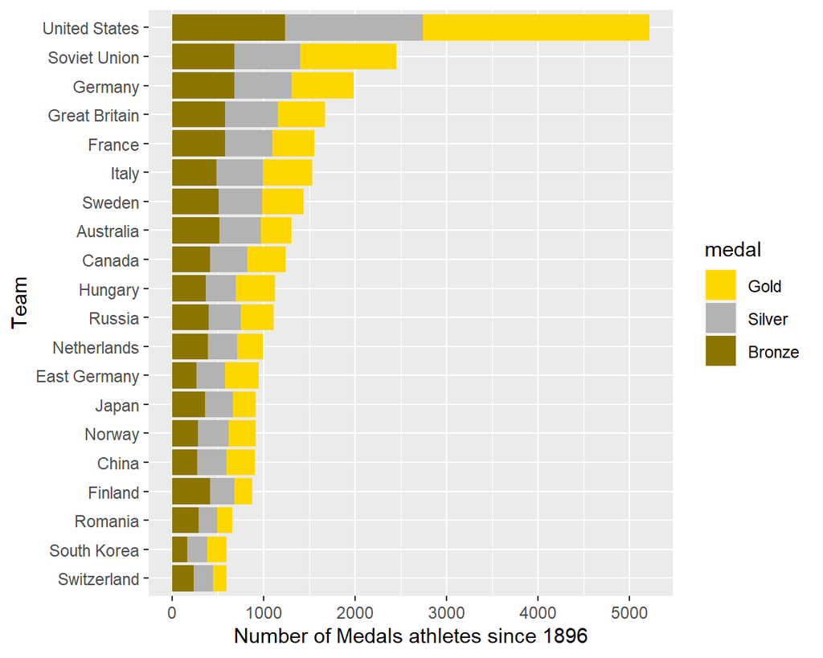

### Number of athletes per countery

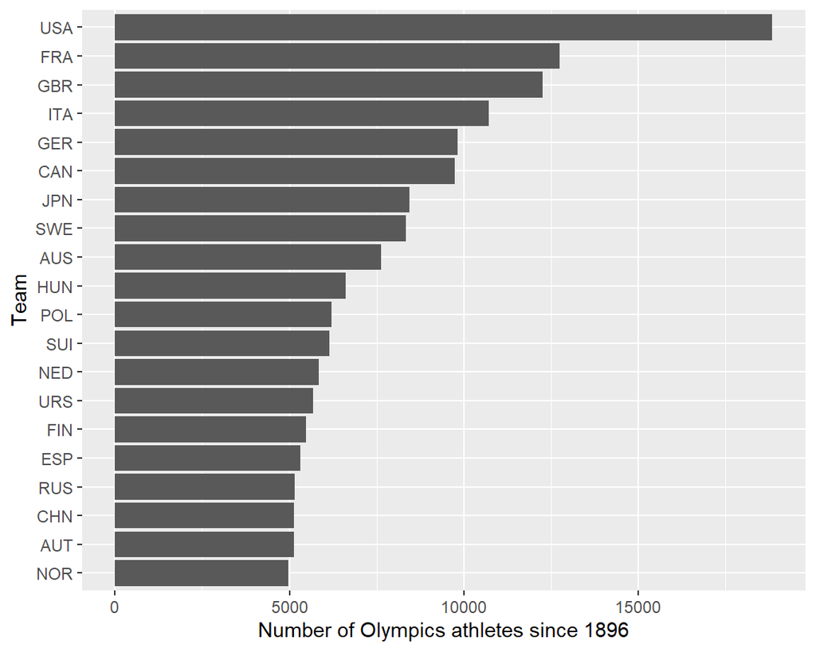

### who got the most medals

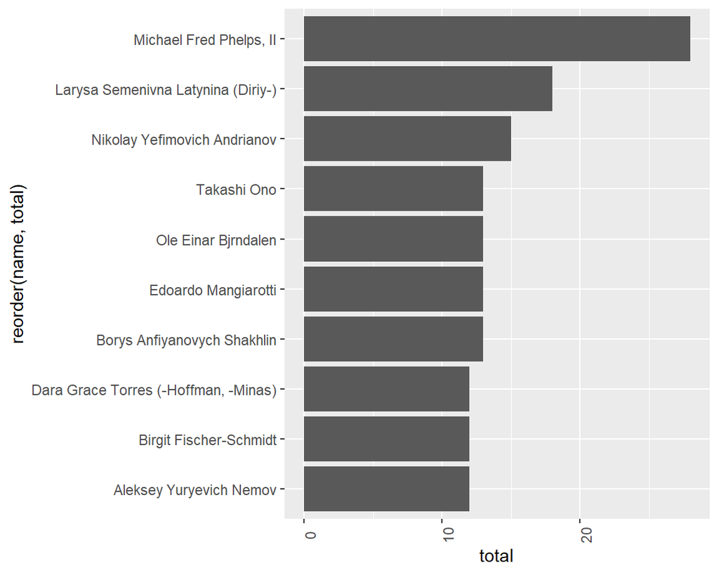

### Findings

Interest NOCs are leading the way for gender equality in the Olympics,so some NOCs even sent a majority of female athletes to the Games ,In 1996 and 2016. The chart shows asimprovement in female participation from 1956 to 2016 .

### know lets take a look if number of female athlete has increased since 1897 and if did why ?

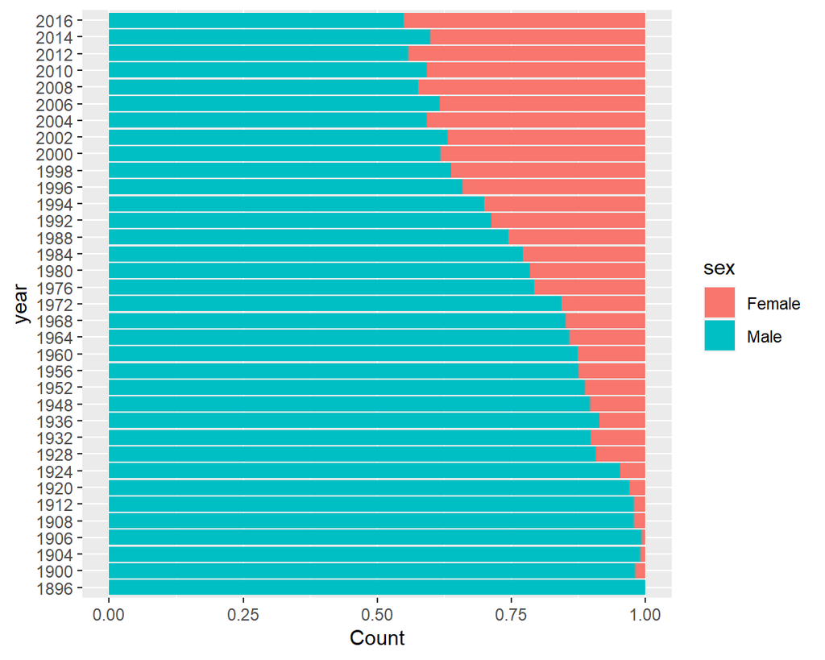

### Findings

**changes of athletes’ height,weight and BMI over time** height, weight has a similar trend it started increase from 1965 and before that the plot shows that the athlete tend to have lower weights, they might thought that decrease in the weight would be better . one thing to notice is that before 1950 there were lots of events that did not need athlete such as art which might affect the result .

## changes of athletes’ height,weight and BMI over time

### Height

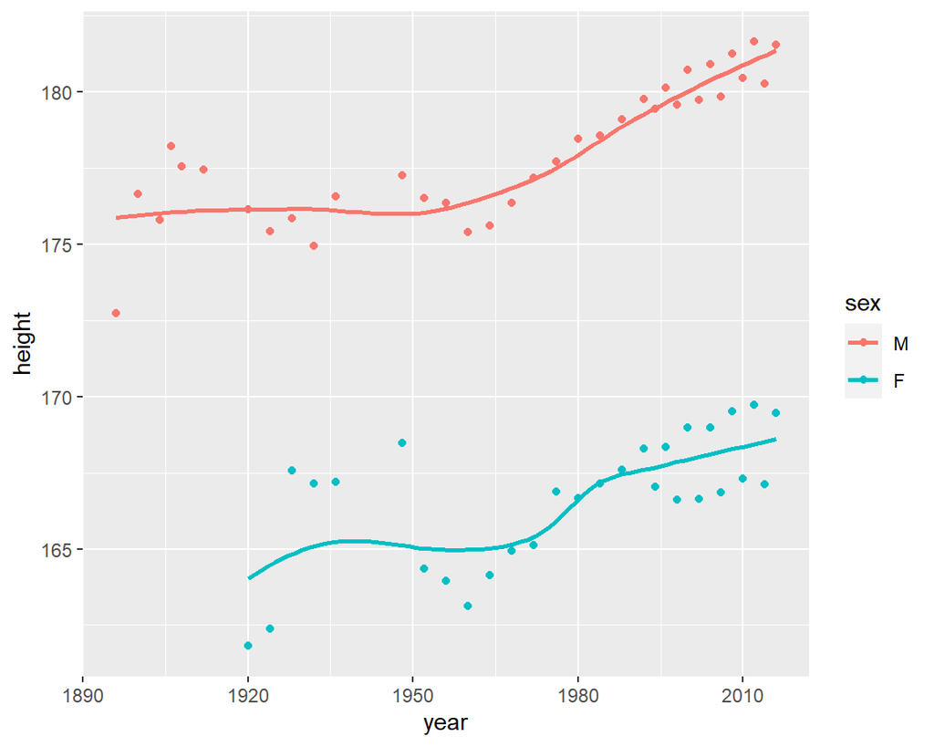

### Weight

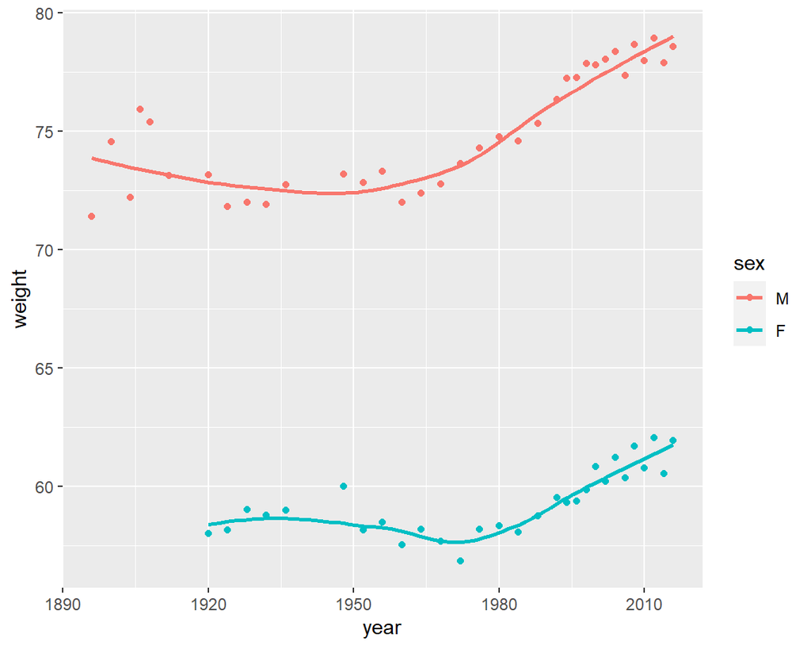

### BMI

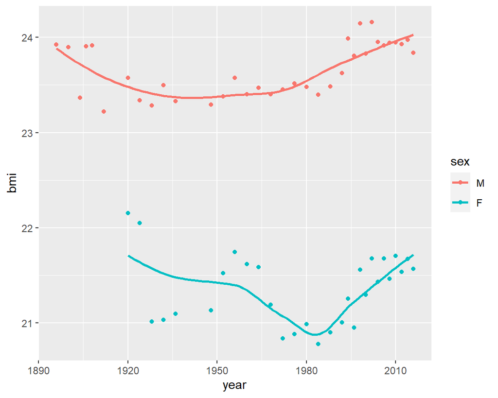

### Example

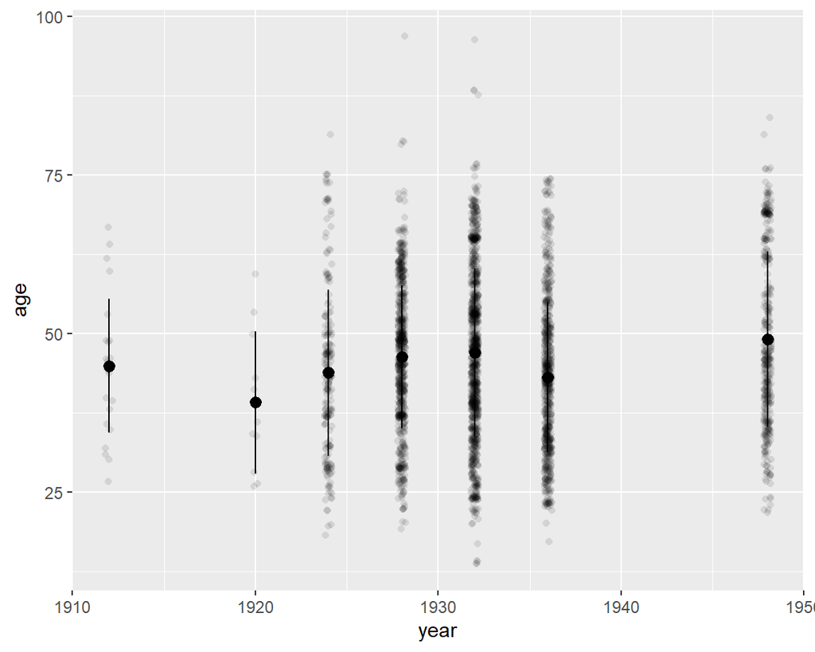

### Findings

this shows that the number of Games decrease in the beginning of WWII and then it increases dynamically after almost 5 years

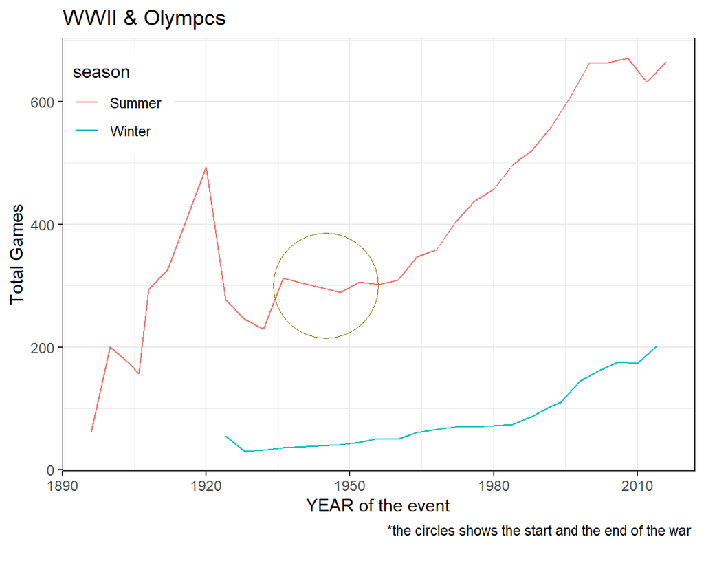

### Findings

this shows the disperse of any German participant between 1939 and 1950 because of the war . The number of participation did not return to before the war until 1967

### **Germany in wrold war 2**

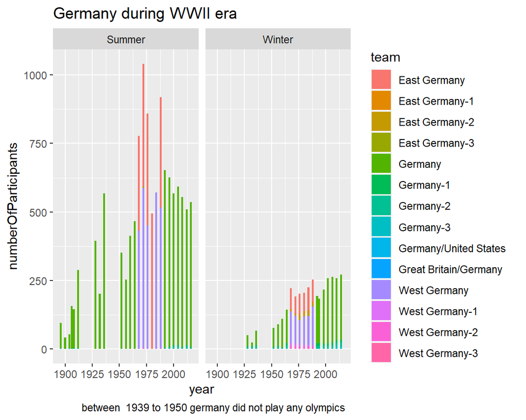

### **Does the age of the athlete effect on his/her performance?**

as we know older people elders are worse in sports than younger, but does this fact also apply on Olympic athlete ?

### **Findings**

in this plot we can see the average age of Olympic athlete since 1897 to 2016,an we can see that mean of age increses between 1912 and 1948, this doesn’t mean their generation was stronger or they were eating healthy this is acullty in those years there was a few events that allows elders to participate and win e.g. art competition.

### **The averege age in each year**

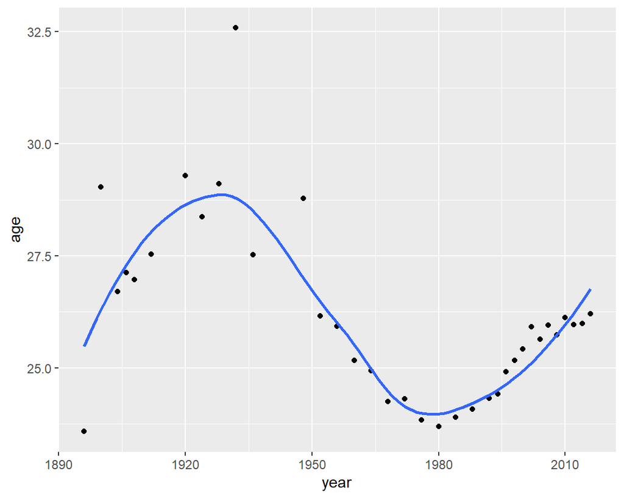

### **Findings**

this plot tells us the density of elder losers is actually higher the the density of elder winners ,so this means yes younger actually have more wining possibility than elders.

### **How old are most of the winners and losers?**

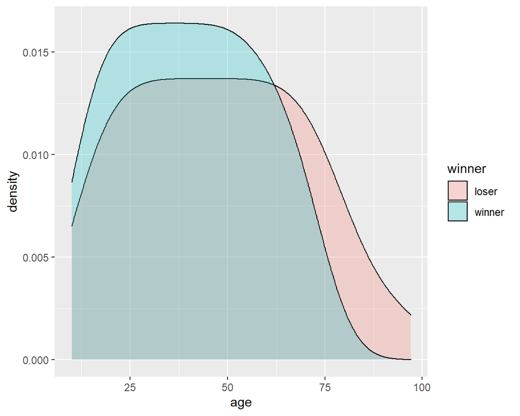

### **Mean of age in year With respect of kind of model**

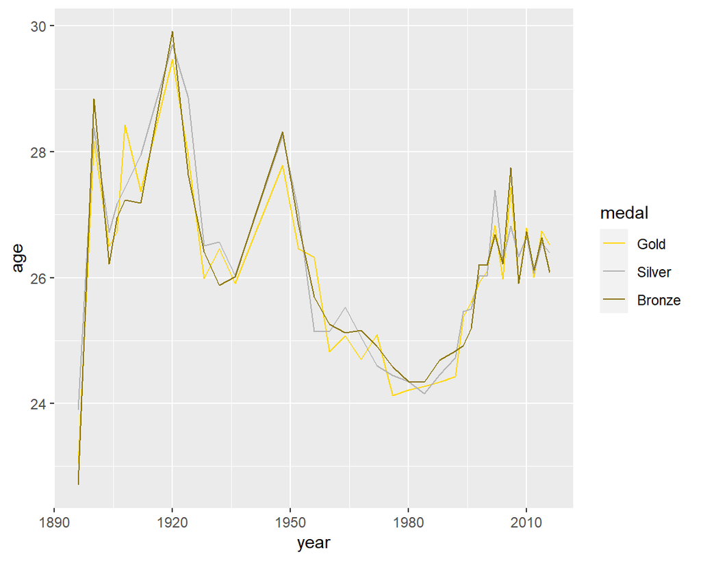

### **kids who got Olympics models(less than 13)**

|  | id | name | sex | age | height | weight | team | noc | games | city | sport | event | medal |
| --- | --- | --- | --- | --- | --- | --- | --- | --- | --- | --- | --- | --- | --- |
| 1 | 74712 | Carla Marangoni | F | 12 |  |  | Italy | ITA | 1928 Summer | Amsterdam | Gymnastics | Gymnastics Women's Team All-Around | Silver |
| 2 | 96664 | Dorothy Poynton-Hill (-Teuber) | F | 12 |  |  | United States | USA | 1928 Summer | Amsterdam | Diving | Diving Women's Springboard | Silver |
| 3 | 113580 | Inge Srensen (-Tabur) | F | 12 |  |  | Denmark | DEN | 1936 Summer | Berlin | Swimming | Swimming Women's 200 metres Breaststroke | Bronze |
| 4 | 125092 | tienne Nol Henri Vandernotte | M | 12 |  | 37 | France | FRA | 1936 Summer | Berlin | Rowing | Rowing Men's Coxed Pairs | Bronze |
| 5 | 125092 | tienne Nol Henri Vandernotte | M | 12 |  | 37 | France | FRA | 1936 Summer | Berlin | Rowing | Rowing Men's Coxed Fours | Bronze |

### **elders who got Olympics models(above 65)**

|  | id | name | sex | age | height | weight | team | noc | games | city | sport | event | medal |
| --- | --- | --- | --- | --- | --- | --- | --- | --- | --- | --- | --- | --- | --- |
| 1 | 22984 | John (Herbert Crawford-) Copley (Williamson-) | M | 73 |  |  | Great Britain | GBR | 1948 Summer | London | Art Competitions | Art Competitions Mixed Painting, Graphic Arts | Silver |
| 2 | 30731 | Jozu Dupon | M | 72 |  |  | Belgium | BEL | 1936 Summer | Berlin | Art Competitions | Art Competitions Mixed Sculpturing, Medals | Bronze |
| 3 | 117046 | Oscar Gomer Swahn | M | 72 |  |  | Sweden | SWE | 1920 Summer | Antwerpen | Shooting | Shooting Men's Running Target, Double Shot, Team | Silver |
| 4 | 75648 | Charles William Martin | M | 71 |  |  | Crabe II-1 | FRA | 1900 Summer | Paris | Sailing | Sailing Mixed 0.5-1 Ton | Silver |
| 5 | 75648 | Charles William Martin | M | 71 |  |  | Crabe II-4 | FRA | 1900 Summer | Paris | Sailing | Sailing Mixed 0.5-1 Ton | Bronze |

# Problems and challenges

- Winter and Summer Games were held in the same year up until 1992. After that, they staggered them such that Winter Games occur on a four year cycle starting with 1994, then Summer in 1996, then Winter in 1998, and so on.  
- How to decide which plots should be presented.  
- There are only a few events that happened every year so it is hard to evaluate the attributes of the athlete without deep analysis.  
- Using git we had some issues in pushing and pulling the content and how we organize our work.  
- In the early years, there is a lot of missing data.

# Key Takeaways from the dataset

- The US has the highest number of medals and athletes.  
- Brazil has the highest number of medals in football.  
- Female participation in the Olympic Games is on the rise.  
- The size of Olympians have become more extreme over time in most sports this means taller and heavier, but in a few sports such as gymnastics, athletes have become smaller.  
- The proportion of winners athletes with ages below 60 is higher than that above 60.  
- The Olympic Games plays a vital role in fostering unity among nations.